# Proportional Odds Logit Modeling for Pacific Oyster Market Traits

Ernest O. Chuku

2023-07-31

## Data

> Read cleaned data and store as data frame - the data is in the S3 data structure.

```r
rm(list = ls()) #clear R environment
```

```r
df_Mktrait <- read.csv("POLM_MarketTraits_data.csv")
```

> View the data structure.

```r
str(df_Mktrait)
```

```
## 'data.frame':    476 obs. of  4 variables:
##  $ Years      : int  25 30 12 32 35 32 6 15 35 30 ...
##  $ SCseg      : chr  "PROD" "PRODTRAD" "TRAD" "PROD" ...
##  $ Mktrait    : chr  "HARD" "HARD" "HARD" "HARD" ...
##  $ MktraitRANK: chr  "agree" "strongly_agree" "agree" "agree" ...
```

> Convert the outcome variable `MktraitRANK` and the other categorical variables `Mktrait` and `SCseg` as factors.

```r
df_Mktrait$MktraitRANK <- as.factor(df_Mktrait$MktraitRANK)
df_Mktrait$Mktrait <- as.factor(df_Mktrait$Mktrait)
df_Mktrait$SCseg <- as.factor(df_Mktrait$SCseg)

str(df_Mktrait)
```

```
## 'data.frame':    476 obs. of  4 variables:
##  $ Years      : int  25 30 12 32 35 32 6 15 35 30 ...
##  $ SCseg      : Factor w/ 3 levels "PROD","PRODTRAD",..: 1 2 3 1 1 1 1 3 1 1 ...
##  $ Mktrait    : Factor w/ 14 levels "BRIT","CI","COL",..: 5 5 5 5 5 5 5 5 5 5 ...
##  $ MktraitRANK: Factor w/ 5 levels "agree","disagree",..: 1 4 1 1 4 4 4 3 4 1 ...
```

> Check the order of the outcome variable.

```r
levels(df_Mktrait$MktraitRANK)
```

```
## [1] "agree"             "disagree"          "not_sure"
## [4] "strongly_agree"    "strongly_disagree"
```

> The outcome variable is ordinal. We, therefore, reorder the ranking levels from least to best. This is critical, and must be done!

```r
df_Mktrait$MktraitRANK <- ordered(df_Mktrait$MktraitRANK,
  levels = c("strongly_disagree", "disagree", "not_sure", "agree", "strongly_agree"))
levels(df_Mktrait$MktraitRANK) # check the levels to confirm reordering
```

```
## [1] "strongly_disagree" "disagree"          "not_sure"
## [4] "agree"             "strongly_agree"
```

```r
contrasts(df_Mktrait$Mktrait)
```

```
##       CI COL CUP HARD MCON MSIZE ROUND SIZE SMELL TASTE TEND TEXT USHP
## BRIT   0   0   0    0    0     0     0    0     0     0    0    0    0
## CI     1   0   0    0    0     0     0    0     0     0    0    0    0
## COL    0   1   0    0    0     0     0    0     0     0    0    0    0
## CUP    0   0   1    0    0     0     0    0     0     0    0    0    0
## HARD   0   0   0    1    0     0     0    0     0     0    0    0    0
## MCON   0   0   0    0    1     0     0    0     0     0    0    0    0
## MSIZE  0   0   0    0    0     1     0    0     0     0    0    0    0
## ROUND  0   0   0    0    0     0     1    0     0     0    0    0    0
## SIZE   0   0   0    0    0     0     0    1     0     0    0    0    0
## SMELL  0   0   0    0    0     0     0    0     1     0    0    0    0
## TASTE  0   0   0    0    0     0     0    0     0     1    0    0    0
## TEND   0   0   0    0    0     0     0    0     0     0    1    0    0
## TEXT   0   0   0    0    0     0     0    0     0     0    0    1    0
## USHP   0   0   0    0    0     0     0    0     0     0    0    0    1
```

```r
contrasts(df_Mktrait$SCseg)
```

```
##          PRODTRAD TRAD
## PROD            0    0
## PRODTRAD        1    0
## TRAD            0    1
```

> Once the data structure is checked we are ready to apply proportional odds logit models

## Fit the Proportional Odds Logistic Regression Models

> The `polr` function from the `MASS` package is used for proportional odds regression.

> We are interested to know the interaction effect of Pddtrait and SCseg so we first go through a restricted modelling process. We compare three models to see which one is the best using likelihood ratios tests.

```r
library(MASS)
```

### POLR Model #1

```r
fit001 <- polr(MktraitRANK ~ Mktrait,
              Hess = TRUE,
              data = df_Mktrait,
              na.action = na.fail)
```

### POLR Model #2

```r
fit002 <- polr(MktraitRANK ~ Mktrait + SCseg,
              Hess = TRUE,
              data = df_Mktrait,
              na.action = na.fail)
```

### POLR Model #3

```r
fit003 <- polr(MktraitRANK ~ Mktrait + SCseg + Mktrait:SCseg,
              Hess = TRUE,
              data = df_Mktrait,
              na.action = na.fail)
```

### Perform likelihood ratio tests of Models 1-3

```r
anova(fit001, fit002, fit003)
```

```
## Likelihood ratio tests of ordinal regression models
##
## Response: MktraitRANK
##                             Model Resid. df Resid. Dev   Test    Df  LR stat.
## 1                         Mktrait       459   1122.125
## 2                 Mktrait + SCseg       457   1118.264 1 vs 2     2  3.860931
## 3 Mktrait + SCseg + Mktrait:SCseg       431   1072.177 2 vs 3    26 46.086977
##      Pr(Chi)
## 1
## 2 0.14508067
## 3 0.00891983
```

```r
step(fit003, test = "Chisq", direction = "both") # perform a forward and backward stepwise model, and perform likelihood ratio test at each step
```

```
## Start:  AIC=1162.18
## MktraitRANK ~ Mktrait + SCseg + Mktrait:SCseg
##
##                 Df    AIC    LRT Pr(>Chi)
## - Mktrait:SCseg 26 1156.3 46.087  0.00892 **
## <none>             1162.2
## ---
## Signif. codes:  0 '***' 0.001 '**' 0.01 '*' 0.05 '.' 0.1 ' ' 1
##
## Step:  AIC=1156.26
## MktraitRANK ~ Mktrait + SCseg
##
##                 Df    AIC     LRT Pr(>Chi)
## - SCseg          2 1156.1   3.861  0.14508
## <none>             1156.3
## + Mktrait:SCseg 26 1162.2  46.087  0.00892 **
## - Mktrait       13 1250.5 120.287  < 2e-16 ***
## ---
## Signif. codes:  0 '***' 0.001 '**' 0.01 '*' 0.05 '.' 0.1 ' ' 1
##
## Step:  AIC=1156.12
## MktraitRANK ~ Mktrait
##
##           Df    AIC     LRT Pr(>Chi)
## <none>       1156.1
## + SCseg    2 1156.3   3.861   0.1451
## - Mktrait 13 1250.0 119.921   <2e-16 ***
## ---
## Signif. codes:  0 '***' 0.001 '**' 0.01 '*' 0.05 '.' 0.1 ' ' 1
```

```
## Call:
## polr(formula = MktraitRANK ~ Mktrait, data = df_Mktrait, na.action = na.fail,
##     Hess = TRUE)
##
## Coefficients:
##    MktraitCI   MktraitCOL   MktraitCUP  MktraitHARD  MktraitMCON MktraitMSIZE
##    1.7207811    1.2769896    0.2366733    1.1468580    3.5967250    2.1679766
## MktraitROUND  MktraitSIZE MktraitSMELL MktraitTASTE  MktraitTEND  MktraitTEXT
##   -0.4927364    1.8724246    1.1904587    0.9290713   -0.6181657    0.1985362
##  MktraitUSHP
##    0.8988278
##
## Intercepts:
## strongly_disagree|disagree          disagree|not_sure
##                  -2.689529                  -1.698234
##             not_sure|agree       agree|strongly_agree
##                  -0.347267                   1.317433
##
## Residual Deviance: 1122.125
## AIC: 1156.125
```

```r
summary(fit003)
```

```
## Call:
## polr(formula = MktraitRANK ~ Mktrait + SCseg + Mktrait:SCseg,
##     data = df_Mktrait, na.action = na.fail, Hess = TRUE)
##
## Coefficients:
##                                Value Std. Error    t value
## MktraitCI                   2.363818  7.779e-01  3.039e+00
## MktraitCOL                  1.720068  7.205e-01  2.387e+00
## MktraitCUP                  0.943949  7.189e-01  1.313e+00
## MktraitHARD                 1.960407  7.107e-01  2.758e+00
## MktraitMCON                 3.652047  9.368e-01  3.899e+00
## MktraitMSIZE                3.757250  9.309e-01  4.036e+00
## MktraitROUND                0.532793  7.097e-01  7.508e-01
## MktraitSIZE                 2.943794  7.877e-01  3.737e+00
## MktraitSMELL                1.122844  7.733e-01  1.452e+00
## MktraitTASTE                0.364310  7.354e-01  4.954e-01
## MktraitTEND                -0.662354  7.038e-01 -9.411e-01
## MktraitTEXT                 0.063536  7.051e-01  9.011e-02
## MktraitUSHP                 1.528139  7.100e-01  2.152e+00
## SCsegPRODTRAD               1.206748  8.065e-01  1.496e+00
## SCsegTRAD                   0.805277  7.095e-01  1.135e+00
## MktraitCI:SCsegPRODTRAD     0.435182  1.454e+00  2.993e-01
## MktraitCOL:SCsegPRODTRAD   -1.720216  1.132e+00 -1.519e+00
## MktraitCUP:SCsegPRODTRAD   -0.721311  1.124e+00 -6.420e-01
## MktraitHARD:SCsegPRODTRAD  -1.240891  1.122e+00 -1.106e+00
## MktraitMCON:SCsegPRODTRAD  11.181562  7.279e-05  1.536e+05
## MktraitMSIZE:SCsegPRODTRAD -0.957199  1.541e+00 -6.211e-01
## MktraitROUND:SCsegPRODTRAD -1.910336  1.141e+00 -1.674e+00
## MktraitSIZE:SCsegPRODTRAD  -1.646285  1.229e+00 -1.339e+00
## MktraitSMELL:SCsegPRODTRAD -0.060884  1.181e+00 -5.154e-02
## MktraitTASTE:SCsegPRODTRAD  0.295572  1.180e+00  2.505e-01
## MktraitTEND:SCsegPRODTRAD  -0.993265  1.108e+00 -8.965e-01
## MktraitTEXT:SCsegPRODTRAD  -0.823617  1.125e+00 -7.318e-01
## MktraitUSHP:SCsegPRODTRAD  -1.252505  1.197e+00 -1.047e+00
## MktraitCI:SCsegTRAD        -1.397630  1.055e+00 -1.324e+00
## MktraitCOL:SCsegTRAD        0.308780  1.051e+00  2.939e-01
## MktraitCUP:SCsegTRAD       -1.352189  1.002e+00 -1.350e+00
## MktraitHARD:SCsegTRAD      -1.199967  1.019e+00 -1.178e+00
## MktraitMCON:SCsegTRAD      -0.009353  1.480e+00 -6.320e-03
## MktraitMSIZE:SCsegTRAD     -2.790899  1.172e+00 -2.381e+00
## MktraitROUND:SCsegTRAD     -1.572713  1.008e+00 -1.560e+00
## MktraitSIZE:SCsegTRAD      -1.480396  1.062e+00 -1.395e+00
## MktraitSMELL:SCsegTRAD      0.360594  1.077e+00  3.347e-01
## MktraitTASTE:SCsegTRAD      1.815132  1.110e+00  1.636e+00
## MktraitTEND:SCsegTRAD       0.829566  1.001e+00  8.289e-01
## MktraitTEXT:SCsegTRAD       1.040461  1.002e+00  1.038e+00
## MktraitUSHP:SCsegTRAD      -0.683935  9.987e-01 -6.848e-01
##
## Intercepts:
##                            Value       Std. Error  t value
## strongly_disagree|disagree     -2.2170      0.5557     -3.9897
## disagree|not_sure              -1.1942      0.5287     -2.2587
## not_sure|agree                  0.2444      0.5190      0.4709
## agree|strongly_agree            2.0343      0.5285      3.8489
##
## Residual Deviance: 1072.177
## AIC: 1162.177
```

> It is easier to interpret the model with p-values instead of the t-values. Calculate the p-values and append to the coefficients table

```r
# get coefficients (it's in matrix form)
coefficients <- summary(fit003)$coefficients
# calculate p-values
p_value <- (1 - pnorm(abs(coefficients[ ,"t value"]), 0, 1))*2
# bind back to coefficients
(coefficients <- cbind(coefficients, p_value))
```

```
##                                  Value   Std. Error       t value      p_value
## MktraitCI                   2.36381843 7.779496e-01  3.038524e+00 2.377404e-03
## MktraitCOL                  1.72006830 7.204956e-01  2.387341e+00 1.697076e-02
## MktraitCUP                  0.94394852 7.188569e-01  1.313124e+00 1.891411e-01
## MktraitHARD                 1.96040673 7.106795e-01  2.758496e+00 5.806794e-03
## MktraitMCON                 3.65204679 9.367738e-01  3.898536e+00 9.677589e-05
## MktraitMSIZE                3.75725028 9.308579e-01  4.036331e+00 5.429370e-05
## MktraitROUND                0.53279298 7.096508e-01  7.507819e-01 4.527839e-01
## MktraitSIZE                 2.94379411 7.876579e-01  3.737402e+00 1.859317e-04
## MktraitSMELL                1.12284384 7.733076e-01  1.452002e+00 1.465012e-01
## MktraitTASTE                0.36431026 7.354142e-01  4.953811e-01 6.203312e-01
## MktraitTEND                -0.66235417 7.038428e-01 -9.410541e-01 3.466771e-01
## MktraitTEXT                 0.06353640 7.051145e-01  9.010792e-02 9.282015e-01
## MktraitUSHP                 1.52813868 7.100498e-01  2.152157e+00 3.138500e-02
## SCsegPRODTRAD               1.20674753 8.065350e-01  1.496212e+00 1.345984e-01
## SCsegTRAD                   0.80527734 7.094716e-01  1.135038e+00 2.563593e-01
## MktraitCI:SCsegPRODTRAD     0.43518219 1.454077e+00  2.992841e-01 7.647233e-01
## MktraitCOL:SCsegPRODTRAD   -1.72021571 1.132160e+00 -1.519410e+00 1.286593e-01
## MktraitCUP:SCsegPRODTRAD   -0.72131094 1.123613e+00 -6.419570e-01 5.209011e-01
## MktraitHARD:SCsegPRODTRAD  -1.24089135 1.121868e+00 -1.106094e+00 2.686859e-01
## MktraitMCON:SCsegPRODTRAD  11.18156165 7.278899e-05  1.536161e+05 0.000000e+00
## MktraitMSIZE:SCsegPRODTRAD -0.95719892 1.541035e+00 -6.211404e-01 5.345073e-01
## MktraitROUND:SCsegPRODTRAD -1.91033625 1.141241e+00 -1.673911e+00 9.414810e-02
## MktraitSIZE:SCsegPRODTRAD  -1.64628543 1.229138e+00 -1.339382e+00 1.804464e-01
## MktraitSMELL:SCsegPRODTRAD -0.06088415 1.181327e+00 -5.153879e-02 9.588962e-01
## MktraitTASTE:SCsegPRODTRAD  0.29557221 1.180091e+00  2.504656e-01 8.022273e-01
## MktraitTEND:SCsegPRODTRAD  -0.99326524 1.107953e+00 -8.964872e-01 3.699926e-01
## MktraitTEXT:SCsegPRODTRAD  -0.82361665 1.125469e+00 -7.317984e-01 4.642917e-01
## MktraitUSHP:SCsegPRODTRAD  -1.25250523 1.196551e+00 -1.046763e+00 2.952088e-01
## MktraitCI:SCsegTRAD        -1.39763010 1.055402e+00 -1.324263e+00 1.854156e-01
## MktraitCOL:SCsegTRAD        0.30877975 1.050663e+00  2.938903e-01 7.688418e-01
## MktraitCUP:SCsegTRAD       -1.35218910 1.001656e+00 -1.349953e+00 1.770310e-01
## MktraitHARD:SCsegTRAD      -1.19996674 1.018649e+00 -1.177998e+00 2.387975e-01
## MktraitMCON:SCsegTRAD      -0.00935255 1.479787e+00 -6.320202e-03 9.949572e-01
## MktraitMSIZE:SCsegTRAD     -2.79089918 1.172186e+00 -2.380935e+00 1.726878e-02
## MktraitROUND:SCsegTRAD     -1.57271342 1.008167e+00 -1.559973e+00 1.187663e-01
## MktraitSIZE:SCsegTRAD      -1.48039621 1.061515e+00 -1.394607e+00 1.631343e-01
## MktraitSMELL:SCsegTRAD      0.36059449 1.077367e+00  3.346996e-01 7.378517e-01
## MktraitTASTE:SCsegTRAD      1.81513162 1.109737e+00  1.635641e+00 1.019146e-01
## MktraitTEND:SCsegTRAD       0.82956564 1.000749e+00  8.289447e-01 4.071357e-01
## MktraitTEXT:SCsegTRAD       1.04046118 1.002318e+00  1.038055e+00 2.992445e-01
## MktraitUSHP:SCsegTRAD      -0.68393456 9.986832e-01 -6.848364e-01 4.934472e-01
## strongly_disagree|disagree -2.21695184 5.556679e-01 -3.989707e+00 6.615510e-05
## disagree|not_sure          -1.19417209 5.287023e-01 -2.258685e+00 2.390297e-02
## not_sure|agree              0.24441298 5.189981e-01  4.709323e-01 6.376891e-01
## agree|strongly_agree        2.03427958 5.285373e-01  3.848886e+00 1.186563e-04
```

> Odds ratios are very useful for explaining the parameter estimates. We calculate the odds ratios and further calculate a less biased version recommended for categorical predictors (Baker, 2006).

```r
# calculate odds ratios
odds_ratio <- exp(coefficients[ ,"Value"]) #this is biased for categorical/dummy variables and tends to slightly overstate the effect
# for reduced bias odds ratios for dummy variables, use
odds_ratio_cat <- exp((coefficients[ ,"Value"])-((((coefficients[ ,"Std. Error"])^2)*(coefficients[ ,"Value"]))/2))
# combine with coefficient and p_value
(coefficients <- cbind(
  coefficients[ ,c("Value", "Std. Error", "p_value")],
  odds_ratio, odds_ratio_cat
))
```

```
##                                  Value   Std. Error      p_value   odds_ratio
## MktraitCI                   2.36381843 7.779496e-01 2.377404e-03 1.063147e+01
## MktraitCOL                  1.72006830 7.204956e-01 1.697076e-02 5.584910e+00
## MktraitCUP                  0.94394852 7.188569e-01 1.891411e-01 2.570110e+00
## MktraitHARD                 1.96040673 7.106795e-01 5.806794e-03 7.102215e+00
## MktraitMCON                 3.65204679 9.367738e-01 9.677589e-05 3.855350e+01
## MktraitMSIZE                3.75725028 9.308579e-01 5.429370e-05 4.283049e+01
## MktraitROUND                0.53279298 7.096508e-01 4.527839e-01 1.703684e+00
## MktraitSIZE                 2.94379411 7.876579e-01 1.859317e-04 1.898775e+01
## MktraitSMELL                1.12284384 7.733076e-01 1.465012e-01 3.073583e+00
## MktraitTASTE                0.36431026 7.354142e-01 6.203312e-01 1.439521e+00
## MktraitTEND                -0.66235417 7.038428e-01 3.466771e-01 5.156360e-01
## MktraitTEXT                 0.06353640 7.051145e-01 9.282015e-01 1.065598e+00
## MktraitUSHP                 1.52813868 7.100498e-01 3.138500e-02 4.609589e+00
## SCsegPRODTRAD               1.20674753 8.065350e-01 1.345984e-01 3.342595e+00
## SCsegTRAD                   0.80527734 7.094716e-01 2.563593e-01 2.237317e+00
## MktraitCI:SCsegPRODTRAD     0.43518219 1.454077e+00 7.647233e-01 1.545245e+00
## MktraitCOL:SCsegPRODTRAD   -1.72021571 1.132160e+00 1.286593e-01 1.790275e-01
## MktraitCUP:SCsegPRODTRAD   -0.72131094 1.123613e+00 5.209011e-01 4.861146e-01
## MktraitHARD:SCsegPRODTRAD  -1.24089135 1.121868e+00 2.686859e-01 2.891264e-01
## MktraitMCON:SCsegPRODTRAD  11.18156165 7.278899e-05 0.000000e+00 7.179439e+04
## MktraitMSIZE:SCsegPRODTRAD -0.95719892 1.541035e+00 5.345073e-01 3.839669e-01
## MktraitROUND:SCsegPRODTRAD -1.91033625 1.141241e+00 9.414810e-02 1.480306e-01
## MktraitSIZE:SCsegPRODTRAD  -1.64628543 1.229138e+00 1.804464e-01 1.927646e-01
## MktraitSMELL:SCsegPRODTRAD -0.06088415 1.181327e+00 9.588962e-01 9.409322e-01
## MktraitTASTE:SCsegPRODTRAD  0.29557221 1.180091e+00 8.022273e-01 1.343895e+00
## MktraitTEND:SCsegPRODTRAD  -0.99326524 1.107953e+00 3.699926e-01 3.703654e-01
## MktraitTEXT:SCsegPRODTRAD  -0.82361665 1.125469e+00 4.642917e-01 4.388416e-01
## MktraitUSHP:SCsegPRODTRAD  -1.25250523 1.196551e+00 2.952088e-01 2.857879e-01
## MktraitCI:SCsegTRAD        -1.39763010 1.055402e+00 1.854156e-01 2.471821e-01
## MktraitCOL:SCsegTRAD        0.30877975 1.050663e+00 7.688418e-01 1.361762e+00
## MktraitCUP:SCsegTRAD       -1.35218910 1.001656e+00 1.770310e-01 2.586734e-01
## MktraitHARD:SCsegTRAD      -1.19996674 1.018649e+00 2.387975e-01 3.012042e-01
## MktraitMCON:SCsegTRAD      -0.00935255 1.479787e+00 9.949572e-01 9.906910e-01
## MktraitMSIZE:SCsegTRAD     -2.79089918 1.172186e+00 1.726878e-02 6.136601e-02
## MktraitROUND:SCsegTRAD     -1.57271342 1.008167e+00 1.187663e-01 2.074814e-01
## MktraitSIZE:SCsegTRAD      -1.48039621 1.061515e+00 1.631343e-01 2.275475e-01
## MktraitSMELL:SCsegTRAD      0.36059449 1.077367e+00 7.378517e-01 1.434182e+00
## MktraitTASTE:SCsegTRAD      1.81513162 1.109737e+00 1.019146e-01 6.141884e+00
## MktraitTEND:SCsegTRAD       0.82956564 1.000749e+00 4.071357e-01 2.292323e+00
```

[output cut: 37 more lines]

```
## MktraitCUP:SCsegTRAD         5.097407e-01
## MktraitHARD:SCsegTRAD        5.613583e-01
## MktraitMCON:SCsegTRAD        1.000888e+00
## MktraitMSIZE:SCsegTRAD       4.174786e-01
## MktraitROUND:SCsegTRAD       4.614140e-01
## MktraitSIZE:SCsegTRAD        5.239646e-01
## MktraitSMELL:SCsegTRAD       1.163369e+00
## MktraitTASTE:SCsegTRAD       2.008624e+00
## MktraitTEND:SCsegTRAD        1.513101e+00
## MktraitTEXT:SCsegTRAD        1.678358e+00
## MktraitUSHP:SCsegTRAD        7.097324e-01
## strongly_disagree|disagree   1.534023e-01
## disagree|not_sure            3.579826e-01
## not_sure|agree               1.235524e+00
## agree|strongly_agree         5.755408e+00
```

### Estimate model fit parameters

```r
nobs(fit003) #observations
```

```
## [1] 476
```

```r
logLik(fit003) #log likelihood
```

```
## 'log Lik.' -536.0883 (df=45)
```

```r
DescTools::PseudoR2(fit003, which = "McFadden")
```

```
##  McFadden
## 0.1367657
```

```r
DescTools::PseudoR2(fit003, which = "Nagelkerke")
```

```
## Nagelkerke
##  0.3239743
```

### Perform type III test for the model

```r
library(car)
Anova(fit003, type = 3, test.statistic = "Wald")
```

```
## Analysis of Deviance Table (Type III tests)
##
## Response: MktraitRANK
##               LR Chisq Df Pr(>Chisq)
## Mktrait         74.865 13  1.009e-10 ***
## SCseg            2.495  2    0.28720
## Mktrait:SCseg   46.087 26    0.00892 **
## ---
## Signif. codes:  0 '***' 0.001 '**' 0.01 '*' 0.05 '.' 0.1 ' ' 1
```

### View the effects

> For POLM, this is a plot of the cumulative probabilities with standard errors. NB: `latent = FALSE` computes effects of POLM as individual-level probabilities and logits. `latent = TRUE` will compute effects of POLM on the scale of the latent response.

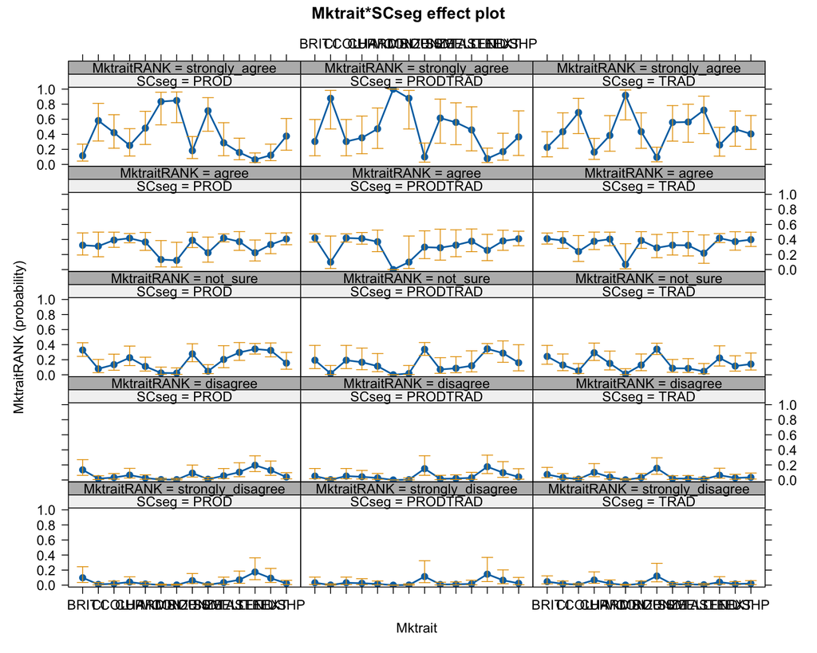

```r
library(effects)
plot(allEffects(fit003))
```

## Dealing with Interaction Term

> We concatenate the variables in the interaction term and refit the model. We go through all the procedures to include p-values, odds ratios, model fit parameters, etc.

### Model #4 (with concateated iteraction term)

```r
#concatenate string/factor variables and store as a new column
df_Mktrait$SCsegTrait <- as.factor(paste(df_Mktrait$SCseg, df_Mktrait$Mktrait, sep = "|")) #combining SCseg and Mktrait
# fit new model
fit004 <- polr(MktraitRANK ~ SCsegTrait,
              Hess = TRUE,
              data = df_Mktrait,
              na.action = na.fail)

# get coefficients (it's in matrix form)
coefficients <- summary(fit004)$coefficients
# calculate p-values
p_value <- (1 - pnorm(abs(coefficients[ ,"t value"]), 0, 1))*2
# bind back to coefficients
coefficients <- cbind(coefficients, p_value)
# calculate odds ratios
odds_ratio <- exp(coefficients[ ,"Value"]) #this is biased for categorical/dummy variables and tends to slightly overstate the effect
# for reduced bias odds ratios for dummy variables, use
odds_ratio_cat <- exp((coefficients[ ,"Value"])-((((coefficients[ ,"Std. Error"])^2)*(coefficients[ ,"Value"]))/2))
# combine with coefficient and p_value
(coefficients <- cbind(
  coefficients[ ,c("Value", "Std. Error", "p_value")],
  odds_ratio, odds_ratio_cat
))
```

```
##                                  Value   Std. Error      p_value   odds_ratio
## SCsegTraitPROD|CI           2.36302949 7.779149e-01 2.384345e-03 1.062309e+01
## SCsegTraitPROD|COL          1.71979424 7.204924e-01 1.698785e-02 5.583380e+00
## SCsegTraitPROD|CUP          0.94419873 7.188613e-01 1.890265e-01 2.570753e+00
## SCsegTraitPROD|HARD         1.96019550 7.106772e-01 5.811921e-03 7.100715e+00
## SCsegTraitPROD|MCON         3.65164879 9.367176e-01 9.685211e-05 3.853815e+01
## SCsegTraitPROD|MSIZE        3.75767303 9.309792e-01 5.431029e-05 4.284860e+01
## SCsegTraitPROD|ROUND        0.53306061 7.096510e-01 4.525571e-01 1.704140e+00
## SCsegTraitPROD|SIZE         2.94396640 7.876881e-01 1.858760e-04 1.899102e+01
## SCsegTraitPROD|SMELL        1.12267464 7.733082e-01 1.465623e-01 3.073063e+00
## SCsegTraitPROD|TASTE        0.36312909 7.354151e-01 6.214656e-01 1.437821e+00
## SCsegTraitPROD|TEND        -0.66258268 7.038427e-01 3.465107e-01 5.155182e-01
## SCsegTraitPROD|TEXT         0.06358426 7.051162e-01 9.281477e-01 1.065649e+00
## SCsegTraitPROD|USHP         1.52790543 7.100482e-01 3.141049e-02 4.608514e+00
## SCsegTraitPRODTRAD|BRIT     1.20652010 8.065354e-01 1.346720e-01 3.341835e+00
## SCsegTraitPRODTRAD|CI       4.00625686 1.189492e+00 7.570427e-04 5.494083e+01
## SCsegTraitPRODTRAD|COL      1.20652010 8.065354e-01 1.346720e-01 3.341835e+00
## SCsegTraitPRODTRAD|CUP      1.42881455 7.973990e-01 7.315797e-02 4.173748e+00
## SCsegTraitPRODTRAD|HARD     1.92589306 8.063204e-01 1.691750e-02 6.861273e+00
## SCsegTraitPRODTRAD|MCON    20.12177343 6.600250e-07 0.000000e+00 5.479932e+08
## SCsegTraitPRODTRAD|MSIZE    4.00625686 1.189492e+00 7.570427e-04 5.494083e+01
## SCsegTraitPRODTRAD|ROUND   -0.17084565 8.218950e-01 8.353321e-01 8.429517e-01
## SCsegTraitPRODTRAD|SIZE     2.50423054 8.898559e-01 4.889915e-03 1.223414e+01
## SCsegTraitPRODTRAD|SMELL    2.26840652 8.332936e-01 6.484541e-03 9.663989e+00
## SCsegTraitPRODTRAD|TASTE    1.86635060 8.617578e-01 3.033042e-02 6.464661e+00
## SCsegTraitPRODTRAD|TEND    -0.44896574 7.876185e-01 5.686577e-01 6.382880e-01
## SCsegTraitPRODTRAD|TEXT     0.44674443 8.082112e-01 5.804298e-01 1.563215e+00
## SCsegTraitPRODTRAD|USHP     1.48229800 9.046133e-01 1.012969e-01 4.403052e+00
## SCsegTraitTRAD|BRIT         0.80503707 7.094714e-01 2.565011e-01 2.236779e+00
## SCsegTraitTRAD|CI           1.77157938 7.427992e-01 1.707892e-02 5.880133e+00
## SCsegTraitTRAD|COL          2.83418922 7.942000e-01 3.588815e-04 1.701660e+01
## SCsegTraitTRAD|CUP          0.39663460 7.178659e-01 5.805928e-01 1.486813e+00
## SCsegTraitTRAD|HARD         1.56500651 7.566037e-01 3.859653e-02 4.782706e+00
## SCsegTraitTRAD|MCON         4.44820058 1.169267e+00 1.422265e-04 8.547300e+01
## SCsegTraitTRAD|MSIZE        1.77157938 7.427992e-01 1.707892e-02 5.880133e+00
## SCsegTraitTRAD|ROUND       -0.23464266 7.327235e-01 7.487913e-01 7.908534e-01
## SCsegTraitTRAD|SIZE         2.26867424 7.447416e-01 2.317097e-03 9.666577e+00
## SCsegTraitTRAD|SMELL        2.28863896 7.779186e-01 3.260966e-03 9.861507e+00
## SCsegTraitTRAD|TASTE        2.98433046 8.538247e-01 4.736182e-04 1.977326e+01
## SCsegTraitTRAD|TEND         0.97247426 7.341534e-01 1.852972e-01 2.644479e+00
```

[output cut: 37 more lines]

```
## SCsegTraitTRAD|CUP           1.342368e+00
## SCsegTraitTRAD|HARD          3.055867e+00
## SCsegTraitTRAD|MCON          4.085494e+00
## SCsegTraitTRAD|MSIZE         3.606884e+00
## SCsegTraitTRAD|ROUND         8.422699e-01
## SCsegTraitTRAD|SIZE          5.152724e+00
## SCsegTraitTRAD|SMELL         4.933978e+00
## SCsegTraitTRAD|TASTE         6.662650e+00
## SCsegTraitTRAD|TEND          2.034808e+00
## SCsegTraitTRAD|TEXT          4.022031e+00
## SCsegTraitTRAD|USHP          3.353435e+00
## strongly_disagree|disagree   1.533856e-01
## disagree|not_sure            3.579364e-01
## not_sure|agree               1.235374e+00
## agree|strongly_agree         5.754788e+00
```

```r
nobs(fit004)
```

```
## [1] 476
```

```r
logLik(fit004)
```

```
## 'log Lik.' -536.0883 (df=45)
```

```r
DescTools::PseudoR2(fit004, which = "McFadden")
```

```
##  McFadden
## 0.1367657
```

```r
DescTools::PseudoR2(fit004, which = "Nagelkerke")
```

```
## Nagelkerke
##  0.3239743
```

```r
Anova(fit004, type = 3, test.statistic = "Wald")
```

```
## Analysis of Deviance Table (Type III tests)
##
## Response: MktraitRANK
##            LR Chisq Df Pr(>Chisq)
## SCsegTrait   169.87 41  < 2.2e-16 ***
## ---
## Signif. codes:  0 '***' 0.001 '**' 0.01 '*' 0.05 '.' 0.1 ' ' 1
```

> Now the estimates are much easier to comprehend. You can observe that Models #3 and #4 are the same!

> Let’s view the effects plot for Model #4. For POLR, this a plot of the cumulative probabilities with standard errors. NB: `latent = FALSE` computes effects of POLR model as individual-level probabilities and logits. `latent = TRUE` will compute effects of POLR model on the scale of the latent response.

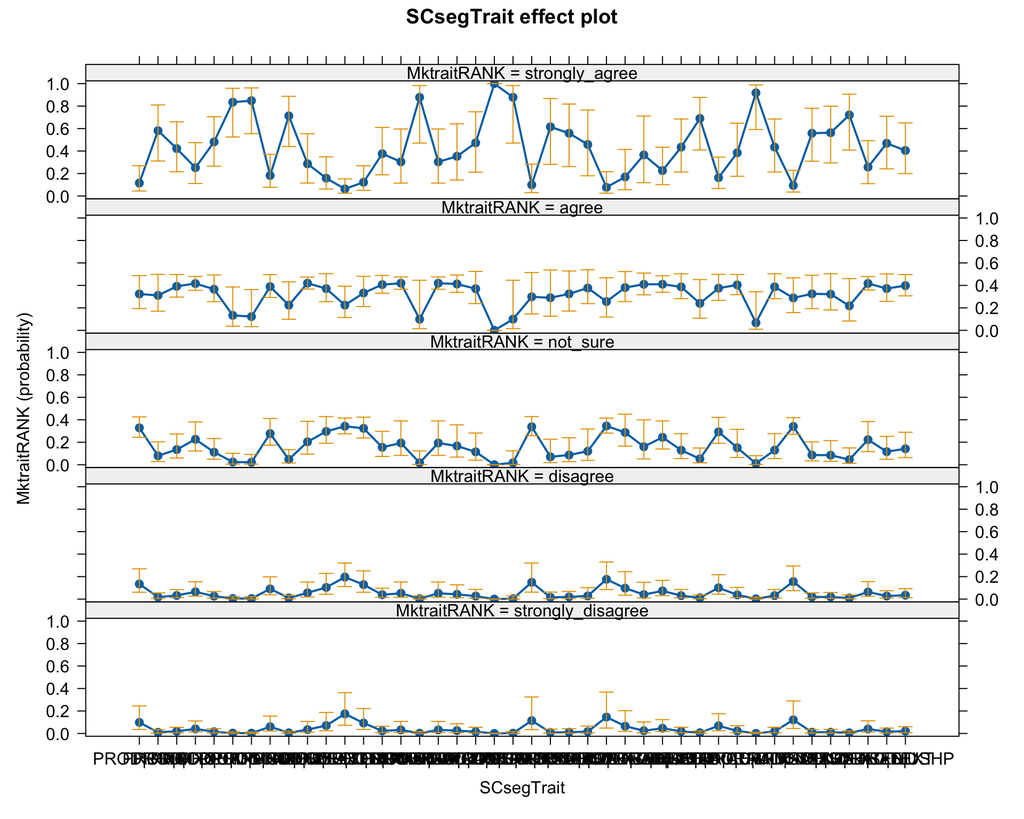

```r
plot(allEffects((fit004), latent = FALSE))
```

> The probability estimates (effects) among the ranks is still the same as for Model #3.

Multiple comparisons of model coefficients

```r
library(emmeans)
#get estimated means coefficients of factor levels for a categorical predictor and store
em <- emmeans(fit004, "SCsegTrait")
#get multiple comparisons OR contrasts among the factor levels
#contrast(em, "pairwise", adjust = "Tukey")
#save multiple comparisons as a dataframe
df_EstCOMP <- data.frame(contrast(em, "pairwise", adjust = "Tukey"), check.names = FALSE, stringsAsFactors = FALSE)
# calculate odds ratios
df_EstCOMP$OR <- round((exp(df_EstCOMP[ ,"estimate"])-1)*100)
# for reduced bias odds ratios for the differences in parameter estimates, use
df_EstCOMP$OR_cat <- round(((exp((df_EstCOMP[ ,"estimate"])-((((df_EstCOMP[ ,"SE"])^2)*(df_EstCOMP[ ,"estimate"]))/2)))-1)*100)
#reorder such that contrasts significant p-values will be on top
df_EstCOMP_ord <- df_EstCOMP[order(df_EstCOMP$p.value),]
# View the reordered contrasts
head(df_EstCOMP_ord)
```

```
##                      contrast  estimate           SE  df       z.ratio p.value
## 19  PROD|BRIT - PRODTRAD|MCON -20.12177 6.600250e-07 Inf -3.048638e+07       0
## 59    PROD|CI - PRODTRAD|MCON -17.75874 7.779153e-01 Inf -2.282863e+01       0
## 98   PROD|COL - PRODTRAD|MCON -18.40198 7.204929e-01 Inf -2.554082e+01       0
## 136  PROD|CUP - PRODTRAD|MCON -19.17757 7.188617e-01 Inf -2.667770e+01       0
## 173 PROD|HARD - PRODTRAD|MCON -18.16158 7.106777e-01 Inf -2.555530e+01       0
## 209 PROD|MCON - PRODTRAD|MCON -16.47012 9.367179e-01 Inf -1.758280e+01       0
##       OR OR_cat
## 19  -100   -100
## 59  -100   -100
## 98  -100   -100
## 136 -100   -100
## 173 -100   -100
## 209 -100   -100
```

Select specific contrasts of model coefficients from `df_EstCOMP_ord` for comparison

```r
df_EstCOMP_ord[is.element(df_EstCOMP_ord$contrast,
                          c('PROD|MCON - PRODTRAD|MCON',
                            'PROD|MCON - TRAD|MCON',
                            'PRODTRAD|MCON - TRAD|MCON')),]
```

```
##                      contrast    estimate        SE  df     z.ratio p.value
## 209 PROD|MCON - PRODTRAD|MCON -16.4701246 0.9367179 Inf -17.5828005       0
## 622 PRODTRAD|MCON - TRAD|MCON  15.6735729 1.1692674 Inf  13.4046092       0
## 223     PROD|MCON - TRAD|MCON  -0.7965518 1.2987237 Inf  -0.6133343       1
##            OR OR_cat
## 209      -100   -100
## 622 641130051  14148
## 223       -55    -12
```

Calculating specific, odds ratios and odds for the contrasts NORMAL (run the code as is)

```r
library(dplyr)

#Subset data
df_EstCOMP_select <- df_EstCOMP %>% filter(contrast == "PROD|MCON - PRODTRAD|MCON")
# for reduced bias odds ratios for the differences in parameter estimates, use
#OR <- ((exp(abs((df_EstCOMP_select[ ,"estimate"]))-(((df_EstCOMP_select[ ,"SE"])^2)/2)))-1)*100
ORcat <- exp((df_EstCOMP_select$estimate)-((((df_EstCOMP_select$SE)^2)*(df_EstCOMP_select$estimate))/2))

#ORcat <- exp((df_EstCOMP_select$estimate)-(((df_EstCOMP_select$SE)^2)/2))
Odds_cat <- (ORcat-1)*100
ORnorm <- exp(df_EstCOMP_select$estimate)
Odds_norm <- (ORnorm-1)*100

ORcat #bias-reduced odds ratio; not appropriate for small odds ratios
```

```
## [1] 9.665646e-05
```

```r
Odds_cat #bias-reduced odds;
```

```
## [1] -99.99033
```

```r
ORnorm #normal odds ratio; biased for categorical variables
```

```
## [1] 7.032597e-08
```

```r
Odds_norm #normal odds
```

```
## [1] -99.99999
```

Calculating specific odds for reverse differences that do not show above; REVERSE negative to positive (use absolute `abs` to convert negative estimate to positive)

```r
#Subset data
df_EstCOMP_select <- df_EstCOMP %>% filter(contrast == "PROD|MCON - PRODTRAD|MCON") #reversing to "PRODTRAD|MCON - PROD|MCON"
# for reduced bias odds ratios for the differences in parameter estimates, use
ORcat <- exp((abs(df_EstCOMP_select$estimate))-((((df_EstCOMP_select$SE)^2)*(abs(df_EstCOMP_select$estimate)))/2))
# the bias-reduced odds; not appropriate for small odds ratios
Odds_cat <- (ORcat-1)*100

#for normal odds ratio
ORnorm <- exp((abs(df_EstCOMP_select$estimate)))
#Normal odds
Odds_norm <- (ORnorm-1)*100

#view the results
ORcat
```

```
## [1] 10345.92
```

```r
Odds_cat
```

```
## [1] 1034492
```

```r
ORnorm
```

```
## [1] 14219497
```

```r
Odds_norm
```

```
## [1] 1421949644
```

Calculating specific odds for reverse differences that do not show above REVERSE positive to negative (multiply the estimate by `-1` to negate it)

```r
#Subset data
df_EstCOMP_select <- df_EstCOMP %>% filter(contrast == "PRODTRAD|MCON - TRAD|MCON")
#Reverse estimate positive to negative
REVestimate <- (-1)*(df_EstCOMP_select$estimate)
# for reduced bias odds ratios for the differences in parameter estimates, use
ORcat <- exp(REVestimate-((((df_EstCOMP_select$SE)^2)*(REVestimate))/2))

Odds_cat <- (ORcat-1)*100
ORnorm <- exp(REVestimate)
Odds_norm <- (ORnorm-1)*100

#view the results
ORcat
```

```
## [1] 0.00701836
```

```r
Odds_cat
```

```
## [1] -99.29816
```

```r
ORnorm
```

```
## [1] 1.559746e-07
```

```r
Odds_norm
```

```
## [1] -99.99998
```

## Estimating predicted probabilities

```r
model_best <- fit003
```

> How does the data frame look like at this point?

```r
head(df_Mktrait)
```

```
##   Years    SCseg Mktrait    MktraitRANK    SCsegTrait
## 1    25     PROD    HARD          agree     PROD|HARD
## 2    30 PRODTRAD    HARD strongly_agree PRODTRAD|HARD
## 3    12     TRAD    HARD          agree     TRAD|HARD
## 4    32     PROD    HARD          agree     PROD|HARD
## 5    35     PROD    HARD strongly_agree     PROD|HARD
## 6    32     PROD    HARD strongly_agree     PROD|HARD
```

> Let’s select on the columns for the predictions, i.e., the variables used in the model.

```r
# only keep what is used in the analysis
df_MktraitRANKselect <- dplyr::select(df_Mktrait, Mktrait, SCseg, MktraitRANK)
levels(df_MktraitRANKselect$MktraitRANK) # check the levels of MktraitRANK again
```

```
## [1] "strongly_disagree" "disagree"          "not_sure"
## [4] "agree"             "strongly_agree"
```

```r
head(df_MktraitRANKselect)
```

```
##   Mktrait    SCseg    MktraitRANK
## 1    HARD     PROD          agree
## 2    HARD PRODTRAD strongly_agree
## 3    HARD     TRAD          agree
## 4    HARD     PROD          agree
## 5    HARD     PROD strongly_agree
## 6    HARD     PROD strongly_agree
```

> Add predicted probabilities to the data frame. These are cumulative probabilities for the ranks.

```r
# add the predicted probabilities to the data frame
df_MktraitRANKselect <- cbind(df_MktraitRANKselect, predict(model_best, type = "probs"))

head(df_MktraitRANKselect) # show the probabilities
```

```
##   Mktrait    SCseg    MktraitRANK strongly_disagree   disagree  not_sure
## 1    HARD     PROD          agree        0.01510724 0.02580400 0.1114767
## 2    HARD PRODTRAD strongly_agree        0.01562377 0.02664839 0.1145785
## 3    HARD     TRAD          agree        0.02225528 0.03727527 0.1510708
## 4    HARD     PROD          agree        0.01510724 0.02580400 0.1114767
## 5    HARD     PROD strongly_agree        0.01510724 0.02580400 0.1114767
## 6    HARD     PROD strongly_agree        0.01510724 0.02580400 0.1114767
##       agree strongly_agree
## 1 0.3660719      0.4815402
## 2 0.3701273      0.4730221
## 3 0.4044420      0.3849566
## 4 0.3660719      0.4815402
## 5 0.3660719      0.4815402
## 6 0.3660719      0.4815402
```

> We tidy up the predicted probabilities for plotting.

```r
library(tidyverse)
# convert the data frame to long format for plotting
df_plot <- gather(df_MktraitRANKselect, key = Predicted, value = Probability, 4:8) #edit column numbers to suit your data frame

head(df_plot) # examine the data
```

```
##   Mktrait    SCseg    MktraitRANK         Predicted Probability
## 1    HARD     PROD          agree strongly_disagree  0.01510724
## 2    HARD PRODTRAD strongly_agree strongly_disagree  0.01562377
## 3    HARD     TRAD          agree strongly_disagree  0.02225528
## 4    HARD     PROD          agree strongly_disagree  0.01510724
## 5    HARD     PROD strongly_agree strongly_disagree  0.01510724
## 6    HARD     PROD strongly_agree strongly_disagree  0.01510724
```

> Remove duplicate rows - rows with repeated probabilities

```r
# only keep the columns we need and remove duplicate rows
df_plot <- df_plot %>% dplyr::select(Mktrait, SCseg, Predicted, Probability) %>%
  unique()
# ensure Predicted column is ordered
df_plot$Predicted <- ordered(df_plot$Predicted,
  levels = c("strongly_disagree", "disagree", "not_sure", "agree", "strongly_agree"))
# rearrange the rows
df_plot <- df_plot %>%  arrange(Mktrait, SCseg, Predicted)

df_plot # look at the whole data frame
```

```
##     Mktrait    SCseg         Predicted  Probability
## 1      BRIT     PROD strongly_disagree 9.823850e-02
## 2      BRIT     PROD          disagree 1.342751e-01
## 3      BRIT     PROD          not_sure 3.282873e-01
## 4      BRIT     PROD             agree 3.235486e-01
## 5      BRIT     PROD    strongly_agree 1.156505e-01
## 6      BRIT PRODTRAD strongly_disagree 3.156295e-02
## 7      BRIT PRODTRAD          disagree 5.153964e-02
## 8      BRIT PRODTRAD          not_sure 1.933084e-01
## 9      BRIT PRODTRAD             agree 4.194218e-01
## 10     BRIT PRODTRAD    strongly_agree 3.041672e-01
## 11     BRIT     TRAD strongly_disagree 4.643168e-02
## 12     BRIT     TRAD          disagree 7.282906e-02
## 13     BRIT     TRAD          not_sure 2.440867e-01
## 14     BRIT     TRAD             agree 4.102964e-01
```

[output cut: 196 more lines]

## Plot stack column chart of predicted probabilities for the model

```r
library(ggplot2)
library(ggthemes)     # provides additional ggplot themes
library(RColorBrewer) # provides additional colors
library(cowplot)      # place multiple ggplots side by side
```

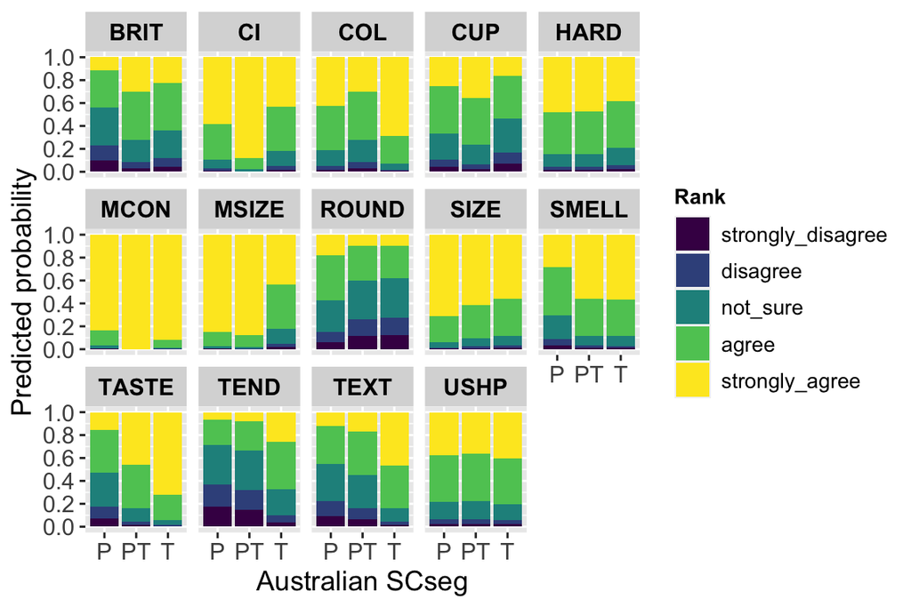

```r
plot_MktraitsRANK <- ggplot(df_plot, aes(x = SCseg, y = Probability, fill = Predicted)) +
  geom_col(position = position_stack(reverse = TRUE)) +
  scale_y_continuous(breaks = c(0.0,0.2,0.4,0.6,0.8,1.0)) +
  facet_wrap(~ Mktrait, ncol=5) +
  labs(x = "Australian SCseg", y = "Predicted probability", fill = "Rank") +
  scale_x_discrete(labels=c("PROD" = "P", "PRODTRAD" = "PT", "TRAD" = "T")) +
theme(legend.title = element_text(size=10, face="bold")) +
  theme(legend.text = element_text(size=10))

plot_MktraitsRANKfin <- plot_MktraitsRANK +
  theme(axis.title.x = element_text(size=13)) +
  theme(axis.title.y = element_text(size=13)) +
  theme(axis.text.x = element_text(size=11)) +
  theme(axis.text.y = element_text(size=11)) +
  theme(strip.text.x = element_text(size = 11, color = "black", face = "bold"))

plot_MktraitsRANKfin
```

## Predict mean categorical rank outcomes for specific traits of in each state

```r
# Get levels of each categorical predictor using the terms in the model
LEVELS1 <- levels(df_MktraitRANKselect$Mktrait)
LEVELS2 <- levels(df_MktraitRANKselect$SCseg)
```

```r
# Create a data.frame to store the predictions
df_predRANKS <- data.frame(
  Mktrait   = rep(LEVELS1, length(LEVELS2)),
  SCseg = rep(LEVELS2, each=length(LEVELS1))
)
```

```r
# Add the predictions
df_predRANKS$predRANKS <- predict(model_best, df_predRANKS)

# View the predicted ranks
df_predRANKS
```

```
##    Mktrait    SCseg      predRANKS
## 1     BRIT     PROD       not_sure
## 2       CI     PROD strongly_agree
## 3      COL     PROD strongly_agree
## 4      CUP     PROD          agree
## 5     HARD     PROD strongly_agree
## 6     MCON     PROD strongly_agree
## 7    MSIZE     PROD strongly_agree
## 8    ROUND     PROD          agree
## 9     SIZE     PROD strongly_agree
## 10   SMELL     PROD          agree
## 11   TASTE     PROD          agree
## 12    TEND     PROD       not_sure
## 13    TEXT     PROD          agree
## 14    USHP     PROD          agree
```

[output cut: 28 more lines]

```r
#sort by SCseg and predRANKS in descending order
df_predRANKS$predRANKS <- ordered(df_predRANKS$predRANKS)
df_predRANKS_ord <- df_predRANKS[order(df_predRANKS$SCseg, df_predRANKS$predRANKS, decreasing = TRUE),]
# View the ordered predicted ranks
df_predRANKS_ord
```

```
##    Mktrait    SCseg      predRANKS
## 30      CI     TRAD strongly_agree
## 31     COL     TRAD strongly_agree
## 34    MCON     TRAD strongly_agree
## 35   MSIZE     TRAD strongly_agree
## 37    SIZE     TRAD strongly_agree
## 38   SMELL     TRAD strongly_agree
## 39   TASTE     TRAD strongly_agree
## 41    TEXT     TRAD strongly_agree
## 42    USHP     TRAD strongly_agree
## 29    BRIT     TRAD          agree
## 32     CUP     TRAD          agree
## 33    HARD     TRAD          agree
## 40    TEND     TRAD          agree
## 36   ROUND     TRAD       not_sure
```

[output cut: 28 more lines]

## Testing the Proportionality Assumption

### Brant-Wald Test

```r
brant::brant(fit001)
```

```
## --------------------------------------------
## Test for X2  df  probability
## --------------------------------------------
## Omnibus      -1601.57    39  1
## MktraitCI    2.82    3   0.42
## MktraitCOL   4955.73 3   0
## MktraitCUP   0.19    3   0.98
## MktraitHARD  0.11    3   0.99
## MktraitMCON  17.41   3   0
## MktraitMSIZE 3.62    3   0.31
## MktraitROUND 1.51    3   0.68
## MktraitSIZE  -679.15 3   1
## MktraitSMELL 3.59    3   0.31
## MktraitTASTE 5.33    3   0.15
## MktraitTEND  7.07    3   0.07
## MktraitTEXT  3.99    3   0.26
## MktraitUSHP  0.77    3   0.86
## --------------------------------------------
##
## H0: Parallel Regression Assumption holds
```

```r
brant::brant(fit002)
```

```
## --------------------------------------------
## Test for X2  df  probability
## --------------------------------------------
## Omnibus      174.59  45  0
## MktraitCI    2.7 3   0.44
## MktraitCOL   0.46    3   0.93
## MktraitCUP   0.19    3   0.98
## MktraitHARD  0.13    3   0.99
## MktraitMCON  16.56   3   0
## MktraitMSIZE 3.51    3   0.32
## MktraitROUND 1.59    3   0.66
## MktraitSIZE  0   3   1
## MktraitSMELL 3.44    3   0.33
## MktraitTASTE 5.27    3   0.15
## MktraitTEND  7.17    3   0.07
## MktraitTEXT  4.02    3   0.26
## MktraitUSHP  0.74    3   0.86
## SCsegPRODTRAD    9.04    3   0.03
## SCsegTRAD    11.06   3   0.01
## --------------------------------------------
##
## H0: Parallel Regression Assumption holds
```

### Graphical Method [Manually Checking the proportional odds assumption (see detailed explanations at https://stats.oarc.ucla.edu/r/dae/ordinal-logistic-regression/)]

```r
library(Hmisc)

sf <- function(y) {
  c('Y>=1' = qlogis(mean(y >= 1)),
    'Y>=2' = qlogis(mean(y >= 2)),
    'Y>=3' = qlogis(mean(y >= 3)),
    'Y>=4' = qlogis(mean(y >= 4)),
    'Y>=5' = qlogis(mean(y >= 5)))
}

(s <- with(df_Mktrait, summary(as.numeric(MktraitRANK) ~ Mktrait + SCseg + Mktrait:SCseg, fun=sf)))
```

```
## as.numeric(MktraitRANK)      N= 476
##
## +-------+--------+---+----+--------+--------+----------+----------+
## |       |        |  N|Y>=1|    Y>=2|    Y>=3|      Y>=4|      Y>=5|
## +-------+--------+---+----+--------+--------+----------+----------+
## |Mktrait|    BRIT| 34| Inf|2.335375|1.757858| 0.6061358|-1.7578579|
## |       |      CI| 34| Inf|3.496508|2.772589| 1.7578579| 0.4795731|
## |       |     COL| 34| Inf|     Inf|     Inf| 1.7578579|-0.1177830|
## |       |     CUP| 34| Inf|     Inf|2.014903| 0.7375989|-1.3499267|
## |       |    HARD| 34| Inf|     Inf|3.496508| 2.0149030|-0.3566749|
## |       |    MCON| 34| Inf|3.496508|2.772589| 2.7725887| 2.3353749|
## |       |   MSIZE| 34| Inf|3.496508|3.496508| 2.3353749| 0.8754687|
## |       |   ROUND| 34| Inf|2.335375|1.021651| 0.0000000|-2.0149030|
## |       |    SIZE| 34| Inf|     Inf|     Inf| 2.7725887| 0.4795731|
## |       |   SMELL| 34| Inf|2.772589|2.014903| 1.3499267| 0.0000000|
## |       |   TASTE| 34| Inf|2.772589|2.014903| 0.8754687|-0.1177830|
## |       |    TEND| 34| Inf|2.335375|1.349927|-0.6061358|-1.5404450|
## |       |    TEXT| 34| Inf|3.496508|2.335375| 0.3566749|-1.0216512|
## |       |    USHP| 34| Inf|3.496508|2.772589| 1.3499267|-0.4795731|
## +-------+--------+---+----+--------+--------+----------+----------+
## |  SCseg|    PROD|196| Inf|2.564949|1.710790| 0.7944009|-0.3504830|
## |       |PRODTRAD|112| Inf|3.592736|3.295837| 1.0986123|-0.1431008|
## |       |    TRAD|168| Inf|5.117994|2.760010| 1.4469190|-0.3120311|
## +-------+--------+---+----+--------+--------+----------+----------+
## |Overall|        |476| Inf|3.236497|2.284236| 1.0763272|-0.2876821|
## +-------+--------+---+----+--------+--------+----------+----------+
```

```r
levels(df_Mktrait$MktraitRANK)
```

```
## [1] "strongly_disagree" "disagree"          "not_sure"
## [4] "agree"             "strongly_agree"
```

```r
summary(glm(I(as.numeric(MktraitRANK) >= 2) ~ Mktrait, family="binomial", data = df_Mktrait))
```

```
##
## Call:
## glm(formula = I(as.numeric(MktraitRANK) >= 2) ~ Mktrait, family = "binomial",
##     data = df_Mktrait)
##
## Coefficients:
##                Estimate Std. Error z value Pr(>|z|)
## (Intercept)   2.335e+00  6.046e-01   3.862 0.000112 ***
## MktraitCI     1.161e+00  1.181e+00   0.983 0.325717
## MktraitCOL    1.823e+01  3.041e+03   0.006 0.995216
## MktraitCUP    1.823e+01  3.041e+03   0.006 0.995216
## MktraitHARD   1.823e+01  3.041e+03   0.006 0.995216
## MktraitMCON   1.161e+00  1.181e+00   0.983 0.325717
## MktraitMSIZE  1.161e+00  1.181e+00   0.983 0.325717
## MktraitROUND -1.263e-15  8.551e-01   0.000 1.000000
## MktraitSIZE   1.823e+01  3.041e+03   0.006 0.995216
## MktraitSMELL  4.372e-01  9.470e-01   0.462 0.644315
## MktraitTASTE  4.372e-01  9.470e-01   0.462 0.644315
## MktraitTEND  -2.197e-15  8.551e-01   0.000 1.000000
## MktraitTEXT   1.161e+00  1.181e+00   0.983 0.325717
## MktraitUSHP   1.161e+00  1.181e+00   0.983 0.325717
## ---
## Signif. codes:  0 '***' 0.001 '**' 0.01 '*' 0.05 '.' 0.1 ' ' 1
##
## (Dispersion parameter for binomial family taken to be 1)
##
##     Null deviance: 153.21  on 475  degrees of freedom
## Residual deviance: 136.42  on 462  degrees of freedom
## AIC: 164.42
##
## Number of Fisher Scoring iterations: 19
```

```r
summary(glm(I(as.numeric(MktraitRANK) >= 3) ~ Mktrait, family="binomial", data = df_Mktrait))
```

```
##
## Call:
## glm(formula = I(as.numeric(MktraitRANK) >= 3) ~ Mktrait, family = "binomial",
##     data = df_Mktrait)
##
## Coefficients:
##               Estimate Std. Error z value Pr(>|z|)
## (Intercept)     1.7579     0.4842   3.630 0.000283 ***
## MktraitCI       1.0147     0.8751   1.160 0.246207
## MktraitCOL     16.8082  1118.6234   0.015 0.988012
## MktraitCUP      0.2570     0.7196   0.357 0.720936
## MktraitHARD     1.7386     1.1246   1.546 0.122110
## MktraitMCON     1.0147     0.8751   1.160 0.246207
## MktraitMSIZE    1.7386     1.1246   1.546 0.122110
## MktraitROUND   -0.7362     0.6210  -1.186 0.235784
## MktraitSIZE    16.8082  1118.6234   0.015 0.988012
## MktraitSMELL    0.2570     0.7196   0.357 0.720936
## MktraitTASTE    0.2570     0.7196   0.357 0.720936
## MktraitTEND    -0.4079     0.6437  -0.634 0.526271
## MktraitTEXT     0.5775     0.7746   0.746 0.455954
## MktraitUSHP     1.0147     0.8751   1.160 0.246207
## ---
## Signif. codes:  0 '***' 0.001 '**' 0.01 '*' 0.05 '.' 0.1 ' ' 1
##
## (Dispersion parameter for binomial family taken to be 1)
##
##     Null deviance: 293.35  on 475  degrees of freedom
## Residual deviance: 260.14  on 462  degrees of freedom
## AIC: 288.14
##
## Number of Fisher Scoring iterations: 17
```

```r
summary(glm(I(as.numeric(MktraitRANK) >= 4) ~ Mktrait, family="binomial", data = df_Mktrait))
```

```
##
## Call:
## glm(formula = I(as.numeric(MktraitRANK) >= 4) ~ Mktrait, family = "binomial",
##     data = df_Mktrait)
##
## Coefficients:
##              Estimate Std. Error z value Pr(>|z|)
## (Intercept)    0.6061     0.3589   1.689  0.09122 .
## MktraitCI      1.1517     0.6027   1.911  0.05602 .
## MktraitCOL     1.1517     0.6027   1.911  0.05602 .
## MktraitCUP     0.1315     0.5130   0.256  0.79775
## MktraitHARD    1.4088     0.6420   2.194  0.02820 *
## MktraitMCON    2.1665     0.8124   2.667  0.00766 **
## MktraitMSIZE   1.7292     0.7031   2.459  0.01392 *
## MktraitROUND  -0.6061     0.4964  -1.221  0.22208
## MktraitSIZE    2.1665     0.8124   2.667  0.00766 **
## MktraitSMELL   0.7438     0.5556   1.339  0.18066
## MktraitTASTE   0.2693     0.5201   0.518  0.60453
## MktraitTEND   -1.2123     0.5075  -2.389  0.01691 *
## MktraitTEXT   -0.2495     0.5002  -0.499  0.61799
## MktraitUSHP    0.7438     0.5556   1.339  0.18066
## ---
## Signif. codes:  0 '***' 0.001 '**' 0.01 '*' 0.05 '.' 0.1 ' ' 1
##
## (Dispersion parameter for binomial family taken to be 1)
##
##     Null deviance: 539.69  on 475  degrees of freedom
## Residual deviance: 466.79  on 462  degrees of freedom
## AIC: 494.79
##
## Number of Fisher Scoring iterations: 5
```

```r
summary(glm(I(as.numeric(MktraitRANK) >= 5) ~ Mktrait, family="binomial", data = df_Mktrait))
```

```
##
## Call:
## glm(formula = I(as.numeric(MktraitRANK) >= 5) ~ Mktrait, family = "binomial",
##     data = df_Mktrait)
##
## Coefficients:
##              Estimate Std. Error z value Pr(>|z|)
## (Intercept)   -1.7579     0.4842  -3.630 0.000283 ***
## MktraitCI      2.2374     0.5992   3.734 0.000188 ***
## MktraitCOL     1.6401     0.5937   2.762 0.005741 **
## MktraitCUP     0.4079     0.6437   0.634 0.526271
## MktraitHARD    1.4012     0.5966   2.349 0.018840 *
## MktraitMCON    4.0932     0.7745   5.285 1.26e-07 ***
## MktraitMSIZE   2.6333     0.6133   4.294 1.76e-05 ***
## MktraitROUND  -0.2570     0.7196  -0.357 0.720934
## MktraitSIZE    2.2374     0.5992   3.734 0.000188 ***
## MktraitSMELL   1.7579     0.5934   2.962 0.003053 **
## MktraitTASTE   1.6401     0.5937   2.762 0.005741 **
## MktraitTEND    0.2174     0.6610   0.329 0.742204
## MktraitTEXT    0.7362     0.6210   1.186 0.235784
## MktraitUSHP    1.2783     0.5992   2.133 0.032895 *
## ---
## Signif. codes:  0 '***' 0.001 '**' 0.01 '*' 0.05 '.' 0.1 ' ' 1
##
## (Dispersion parameter for binomial family taken to be 1)
##
##     Null deviance: 650.13  on 475  degrees of freedom
## Residual deviance: 543.01  on 462  degrees of freedom
## AIC: 571.01
##
## Number of Fisher Scoring iterations: 4
```

```r
s[, 6] <- s[, 6] - s[, 5]
s[, 5] <- s[, 5] - s[, 5]

s # print
```

```
## as.numeric(MktraitRANK)      N= 476
##
## +-------+--------+---+----+--------+--------+----+----------+
## |       |        |  N|Y>=1|    Y>=2|    Y>=3|Y>=4|      Y>=5|
## +-------+--------+---+----+--------+--------+----+----------+
## |Mktrait|    BRIT| 34| Inf|2.335375|1.757858|   0|-2.3639937|
## |       |      CI| 34| Inf|3.496508|2.772589|   0|-1.2782848|
## |       |     COL| 34| Inf|     Inf|     Inf|   0|-1.8756410|
## |       |     CUP| 34| Inf|     Inf|2.014903|   0|-2.0875257|
## |       |    HARD| 34| Inf|     Inf|3.496508|   0|-2.3715780|
## |       |    MCON| 34| Inf|3.496508|2.772589|   0|-0.4372138|
## |       |   MSIZE| 34| Inf|3.496508|3.496508|   0|-1.4599062|
## |       |   ROUND| 34| Inf|2.335375|1.021651|   0|-2.0149030|
## |       |    SIZE| 34| Inf|     Inf|     Inf|   0|-2.2930156|
## |       |   SMELL| 34| Inf|2.772589|2.014903|   0|-1.3499267|
## |       |   TASTE| 34| Inf|2.772589|2.014903|   0|-0.9932518|
## |       |    TEND| 34| Inf|2.335375|1.349927|   0|-0.9343092|
## |       |    TEXT| 34| Inf|3.496508|2.335375|   0|-1.3783262|
## |       |    USHP| 34| Inf|3.496508|2.772589|   0|-1.8294998|
## +-------+--------+---+----+--------+--------+----+----------+
## |  SCseg|    PROD|196| Inf|2.564949|1.710790|   0|-1.1448839|
## |       |PRODTRAD|112| Inf|3.592736|3.295837|   0|-1.2417131|
## |       |    TRAD|168| Inf|5.117994|2.760010|   0|-1.7589501|
## +-------+--------+---+----+--------+--------+----+----------+
## |Overall|        |476| Inf|3.236497|2.284236|   0|-1.3640093|
## +-------+--------+---+----+--------+--------+----+----------+
```

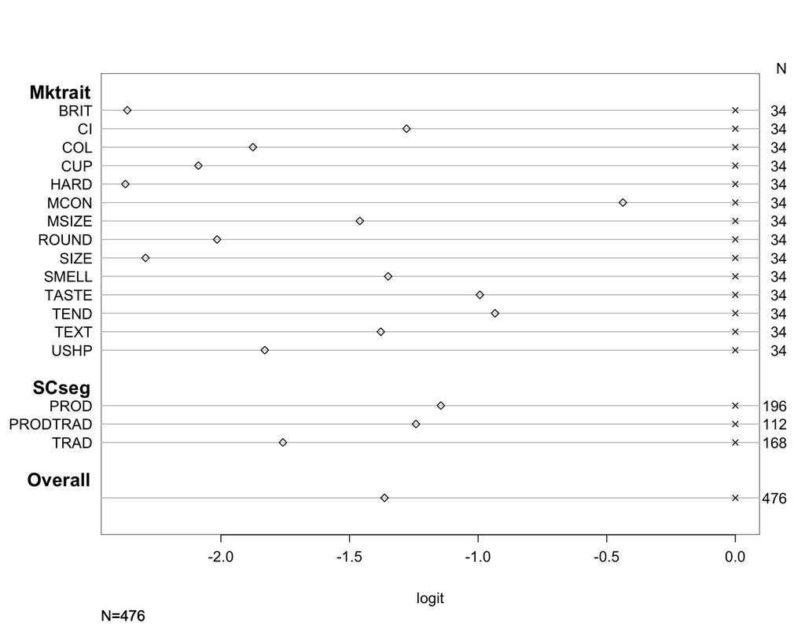

```r
plot(s, which=1:5, pch=1:5, xlab='logit', main=' ', xlim=range(s[,5:6]))
```